# Data Analysis and Model Prediction on Patient Data

### Data Preparation

```r
data1 <- data.frame(read.table("./00_raw_data/Data1.txt", header = T))
data2 <- data.frame(read.table("./00_raw_data/Data2.txt", header = T))
```

```r
# Use dplyr to merge data to keep positions of their ID
library(dplyr)
# Merge the data frames on the ID column
data <- left_join(data1, data2, by = "id")
View(data)
```

```r
# Check for duplicate
sum(duplicated(data))
```

```
[1] 0
```

```r
# Check for Na's
colnames(data)[apply(data, 2, anyNA)]
```

```
[1] "heartRate" "testA"     "testB"     "testC"     "testD"     "testE"     "disease"
```

```r
# Replace Na's in all variables/columns with median

# For heart Rate
median(data$heartRate, na.rm = T)
```

```
[1] 66
```

```r
data$heartRate[is.na(data$heartRate)] <- median(data$heartRate, na.rm = T)

# For test A
median(data$testA, na.rm = T)
```

```
[1] 50
```

```r
data$testA[is.na(data$testA)] <- median(data$testA, na.rm = T)

# For test B
median(data$testB, na.rm = T)
```

```
[1] 50
```

```r
data$testB[is.na(data$testB)] <- median(data$testB, na.rm = T)

# For test C
median(data$testC, na.rm =T)
```

```
[1] 51
```

```r
data$testC[is.na(data$testC)] <- median(data$testC, na.rm = T)

# For test D
median(data$testD, na.rm = T)
```

```
[1] 50
```

```r
data$testD[is.na(data$testD)] <- median(data$testD, na.rm = T)

# For test E
median(data$testE, na.rm = T)
```

```
[1] 43
```

```r
data$testE[is.na(data$testE)] <- median(data$testE, na.rm = T)

# For disease
median(data$disease, na.rm = T)
```

```
[1] 1
```

```r
data$disease[is.na(data$disease)] <- median(data$disease, na.rm = T)
```

```r
# check for Na's
colnames(data)[apply(data, 2, anyNA)]
```

```
character(0)
```

### Exploratory Data Analysis

```r
summary(data$age)
```

```
   Min. 1st Qu.  Median    Mean 3rd Qu.    Max.
  11.00   37.00   44.00   42.84   49.00   76.00
```

The summary of the age variable gives insight to the distribution of ages in dataset: The age ranges from 11 years to 76 years. The average is 43 years Half of the participants are younger than 44 years (median) and half are older.  
25% of the participants are younger than 37 years (1st quartile).  
25% of the participants are older than 49 years (3rd quartile).  
The mean value is less than the median, indicating the data is negatively skewed.

```r
# View the internal structure of the data
str(data)
```

```
'data.frame':   19998 obs. of  16 variables:
 $ id       : int  33418 51079 41242 32003 39742 47264 40173 32269 40332 36629 ...
 $ age      : int  33 44 46 35 46 50 40 44 49 39 ...
 $ ethnic   : int  1 4 0 1 0 4 3 2 1 0 ...
 $ income   : int  3 2 2 3 0 4 0 2 3 0 ...
 $ marital  : int  0 0 1 0 1 1 1 1 0 1 ...
 $ occGroup : int  1 1 8 5 5 2 7 8 2 6 ...
 $ gender   : int  1 0 0 1 0 1 0 1 1 1 ...
 $ weight   : int  144 187 175 140 182 206 173 115 190 173 ...
 $ height   : int  65 60 64 65 62 61 69 62 64 69 ...
 $ heartRate: num  75 64 54 71 66 63 59 69 93 60 ...
 $ testA    : num  48 60 59 41 40 52 36 61 64 67 ...
 $ testB    : num  68 51 58 71 64 50 52 34 36 49 ...
 $ testC    : num  59 45 54 37 50 46 35 63 41 58 ...
 $ testD    : num  45 41 43 56 42 66 66 61 26 47 ...
 $ testE    : num  42 34 30 50 13 73 35 50 56 50 ...
 $ disease  : num  1 0 0 1 1 1 0 0 1 1 ...
```

```r
# Convert the independent variable to a factor / levels  and view the structure
data[,'disease'] <- as.factor(data[,'disease'])
```

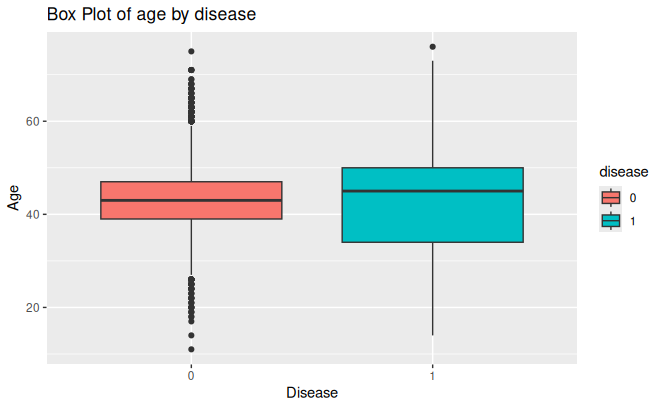

```r
# Using box plot to visualize the data
library(ggplot2)
ggplot(data, aes(x=disease, y=age, fill=disease))+geom_boxplot()+
  labs(title = "Box Plot of age by disease", x = "Disease", y ="Age")
```

**Analysis from the Box Plot:**

The Box plot compared the age for two groups: those without the disease(0) and those with the disease(1). The median age for those with the disease appears to be slightly higher than for those without the disease. The box for those without the disease is smaller indicating less variability in age. The box for those with the disease is larger suggesting more age variability among those with the disease.

In summary while there are some differences in age between those with and without the disease or while age may play a role, the presence of outliers suggest age alone may not be a definite predictor of disease status

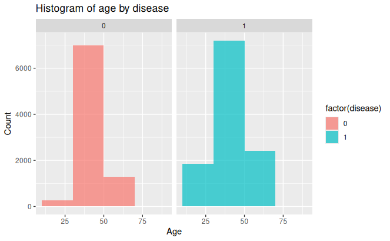

```r
ggplot(data, aes(x=age, fill=factor(disease))) +
  geom_histogram(position="identity", alpha=0.7, binwidth = 20) +
  facet_wrap(~disease) +
  labs(title = "Histogram of age by disease", x = "Age", y = "Count")
```

**Analysis from the graph**

The plot is divided into two panels, one for each disease(0 and 1). The x-axis represent the age, ranging from 0 to 100 years. The y-axis shows the count of individuals in each age group  
**Disease = 0(left panel; pink)** The absence of no disease distribution appears to be skewed. Also there is a very high peak in the 25 - 50 age range. A sharp decline occurs after age 50. Very few individuals are the oldest age group(50 - 75)

In summary, those with the disease group has a more even distribution across age groups. Those without the disease is heavily concentrated in the younger age range. Younger individuals (25-50) without the disease are over represented in the sample. The presence of the disease seems to be associated with a more even age distribution, possibly suggesting it affects people across a broader age spectrum. The disease=0 group’s sharp decline after 50 could indicate that older individuals without the disease are underrepresented in the sample, or that the disease becomes more common with age. There might be potential biases; The sample might not be representative of the general population, given the strong skew in the absence of disease group. There could be age-related factors influencing disease diagnosis or study participation. This complex study relationship between age and disease warrant further investigation

**Scatter plot**

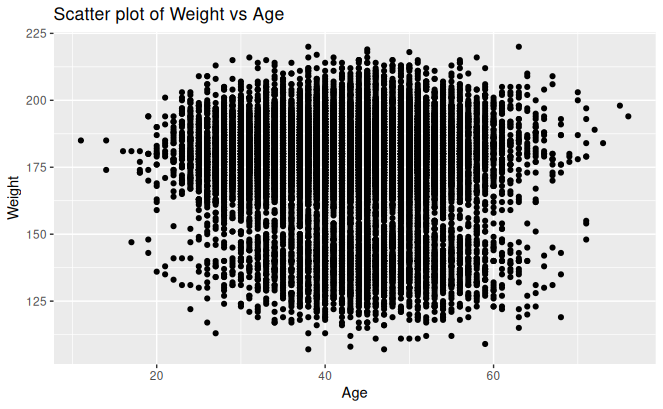

```r
ggplot(data, aes(x = age, y = weight)) +
  geom_point() +
  labs(title = "Scatter plot of Weight vs Age", x = "Age", y = "Weight")
```

### Further Analysis Using Confirmatory Data Analysis

**Logistic regression(lg)**  
Ho = Age is not a factor to contracting the disease.  
H1 = Age is a factor to contract the disease.

```r
lg <- glm(disease ~ age,  family = "binomial", data = data)
summary(lg)
```

```
Call:
glm(formula = disease ~ age, family = "binomial", data = data)

Coefficients:
             Estimate Std. Error z value Pr(>|z|)
(Intercept)  0.721250   0.072970   9.884  < 2e-16 ***
age         -0.009953   0.001666  -5.974 2.32e-09 ***
---
Signif. codes:  0 ‘***’ 0.001 ‘**’ 0.01 ‘*’ 0.05 ‘.’ 0.1 ‘ ’ 1

(Dispersion parameter for binomial family taken to be 1)

    Null deviance: 27295  on 19997  degrees of freedom
Residual deviance: 27259  on 19996  degrees of freedom
AIC: 27263

Number of Fisher Scoring iterations: 4
```

**CHI-SQUARE TEST**  
Ho = No Significant association between marital status and ethnic group.  
H1 = There is significant association between marital status and ethnic group.

```r
chisq = chisq.test(data$ethnic, data$marital)
chisq
```

```
    Pearson's Chi-squared test

data:  data$ethnic and data$marital
X-squared = 6.4592, df = 5, p-value = 0.2641
```

Based on the analysis, the p value (0.2641) is greater than the significant level(0.05). Therefore we accept the null hypothesis and reject the alternative hypothesis, which confirms that there is no significant association between marital status and ethnic group

**Linear Regression**  
Ho = Age does not contribute to height  
H1 = Age does contribute to height

```r
lr <- lm(age ~ height, data)
summary(lr)
```

```
Call:
lm(formula = age ~ height, data = data)

Residuals:
    Min      1Q  Median      3Q     Max
-31.834  -5.840   1.119   6.166  33.180

Coefficients:
             Estimate Std. Error t value Pr(>|t|)
(Intercept) 43.280501   1.511981  28.625   <2e-16 ***
height      -0.006772   0.023227  -0.292    0.771
---
Signif. codes:  0 ‘***’ 0.001 ‘**’ 0.01 ‘*’ 0.05 ‘.’ 0.1 ‘ ’ 1

Residual standard error: 8.608 on 19996 degrees of freedom
Multiple R-squared:  4.251e-06, Adjusted R-squared:  -4.576e-05
F-statistic: 0.085 on 1 and 19996 DF,  p-value: 0.7706
```

Based on the analysis, the p value(0.7706) is greater than the sign. value(0.05) Therefore we accept the null hypothesis and conclude age does not contribute to height.

### **A supervised classification tree model for disease prediction.**

```r
# Check the structure of your data
str(data)
```

```
'data.frame':   19998 obs. of  16 variables:
 $ id       : int  33418 51079 41242 32003 39742 47264 40173 32269 40332 36629 ...
 $ age      : int  33 44 46 35 46 50 40 44 49 39 ...
 $ ethnic   : int  1 4 0 1 0 4 3 2 1 0 ...
 $ income   : int  3 2 2 3 0 4 0 2 3 0 ...
 $ marital  : int  0 0 1 0 1 1 1 1 0 1 ...
 $ occGroup : int  1 1 8 5 5 2 7 8 2 6 ...
 $ gender   : int  1 0 0 1 0 1 0 1 1 1 ...
 $ weight   : int  144 187 175 140 182 206 173 115 190 173 ...
 $ height   : int  65 60 64 65 62 61 69 62 64 69 ...
 $ heartRate: num  75 64 54 71 66 63 59 69 93 60 ...
 $ testA    : num  48 60 59 41 40 52 36 61 64 67 ...
 $ testB    : num  68 51 58 71 64 50 52 34 36 49 ...
 $ testC    : num  59 45 54 37 50 46 35 63 41 58 ...
 $ testD    : num  45 41 43 56 42 66 66 61 26 47 ...
 $ testE    : num  42 34 30 50 13 73 35 50 56 50 ...
 $ disease  : Factor w/ 2 levels "0","1": 2 1 1 2 2 2 1 1 2 2 ...
```

```r
# levels
levels(data$disease) = c(0,1)
```

```r
# let n be the variable that holds the number of rows
n <- nrow(data)
n
```

```
[1] 19998
```

```r
# 80% for training
trainIndex <- sample(1:n, size = round(0.8*n), replace = FALSE)
train <- data[trainIndex,]

# 20% for testing
test <- data[-trainIndex,]

# set seed
set.seed(1)
```

```r
# rpart
library(rpart)
library(rpart.plot)
mod <- rpart(disease~., train)
mod
```

```
n= 15998

node), split, n, loss, yval, (yprob)
      * denotes terminal node

  1) root 15998 6853 1 (0.42836605 0.57163395)
    2) heartRate>=70.5 5876 2164 0 (0.63172226 0.36827774)
      4) ethnic< 0.5 1250  148 0 (0.88160000 0.11840000) *
      5) ethnic>=0.5 4626 2016 0 (0.56420233 0.43579767)
       10) ethnic>=2.5 796  114 0 (0.85678392 0.14321608) *
       11) ethnic< 2.5 3830 1902 0 (0.50339426 0.49660574)
         22) testB< 50.5 1715  780 0 (0.54518950 0.45481050)
           44) weight< 162.5 932   32 0 (0.96566524 0.03433476) *
           45) weight>=162.5 783   35 1 (0.04469987 0.95530013) *
         23) testB>=50.5 2115  993 1 (0.46950355 0.53049645)
           46) weight>=163.5 978  145 0 (0.85173824 0.14826176) *
           47) weight< 163.5 1137  160 1 (0.14072120 0.85927880) *
    3) heartRate< 70.5 10122 3141 1 (0.31031417 0.68968583)
      6) age>=32.5 8137 2998 1 (0.36844046 0.63155954)
       12) age< 44.5 4018 1753 0 (0.56371329 0.43628671)
         24) testE< 37.5 2009  384 0 (0.80886013 0.19113987) *
         25) testE>=37.5 2009  640 1 (0.31856645 0.68143355)
           50) gender< 0.5 835  380 1 (0.45508982 0.54491018)
            100) age>=37.5 424  101 0 (0.76179245 0.23820755) *
            101) age< 37.5 411   57 1 (0.13868613 0.86131387) *
           51) gender>=0.5 1174  260 1 (0.22146508 0.77853492) *
       13) age>=44.5 4119  733 1 (0.17795581 0.82204419) *
      7) age< 32.5 1985  143 1 (0.07204030 0.92795970) *
```

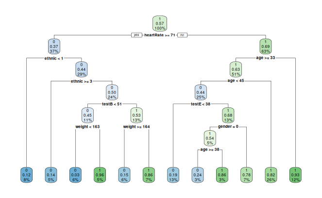

```r
# predict
rpart.plot(mod)
```

```r
pred <- predict(mod, test, type = "vector")
pred
```

[output not shown]

[output cut: 74 more lines]

```r
# actual
act <- test[,'disease']
```

**Model’s Accuracy**

```r
# accuracy
confusion_matrix <- table(pred, act)
confusion_matrix
```

```
    act
pred    0    1
   1 1321  249
   2  364 2066
```

```r
# Calculate accuracy
accuracy <- sum(diag(confusion_matrix)) / sum(confusion_matrix)
print(paste("Accuracy:", round(accuracy*100, 2), "%"))
```

```
[1] "Accuracy: 84.67 %"
```

The model seems to perform reasonably well overall, with an accuracy of 84%. This confusion matrix provides valuable insights into the model’s performance and can help guide further refinement or decision-making based on the model’s predictions.

**Important Features**

```r
# this shows which variables are in important or influential in my model
importance <- mod$variable.importance
importance_df <- data.frame(feature = names(importance), importance = importance)
importance_df <- importance_df[order(-importance_df$importance),]
print(importance_df)
```

|  | feature | importance |
| --- | --- | --- |
| weight | weight | 1479.095982 |
| age | age | 1117.007105 |
| heartRate | heartRate | 895.578011 |
| testE | testE | 734.634353 |
| ethnic | ethnic | 415.865804 |
| gender | gender | 411.083967 |
| testC | testC | 133.112203 |
| testB | testB | 112.228767 |
| id | id | 26.151791 |
| testD | testD | 19.118127 |

[output cut: 2 more lines]

**Deployment**